# PRESS 2016 - COUNTRY FACTSHEETS

```
                                       Guatemala
```

Download this factsheet as PDF

The PRESS exercise is conducted annually to report on trends across time in support to statistics. The 2016 PRESS uses newly available data from an annual donor survey and the Creditor Reporting System (CRS) round of 2014 to update figures on aid to statistics for 2006 to 2013 (previously reported in the 2015 PRESS) and report new figures for commitments in 2014. The new 2014 figures are expected to be adjusted upwards to the levels of previous years 2011-2013 as additional projects for 2014 will be reported later this year.All findings should therefore be interpreted with this caveat in mind.

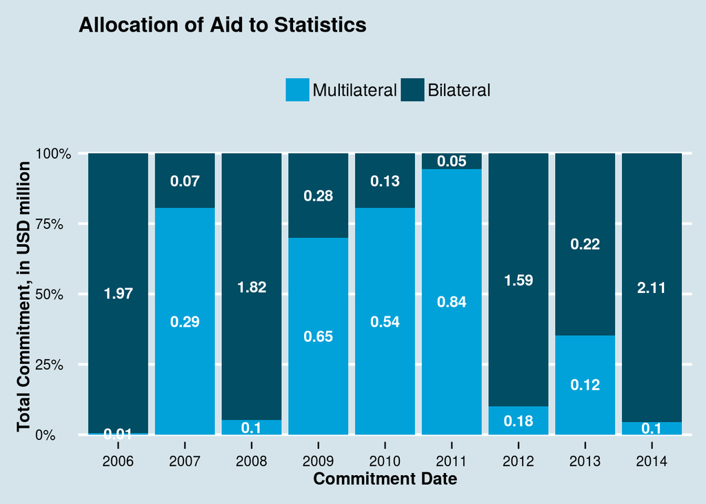

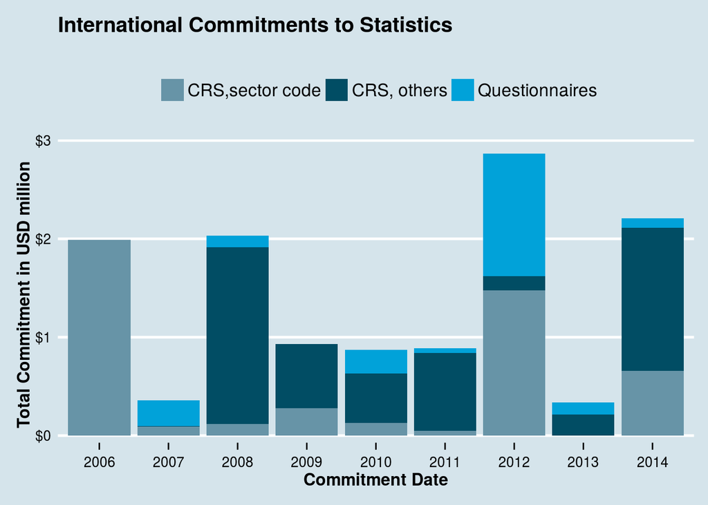

> Fig1. Allocation of Aid to Statistics

Multilateral[^1], country-specific assistance remains globally the most popular means through which donors channel support to countries. Considering all recipients reported in the PRESS, support from multilateral bodies accounted for less than 50% of total aid to statistics in 2009-2010 but increased to approximately 70% in 2011 and 2012, respectively. However, the shares of country-specific[^2] aid diminished slightly between 2012 and 2014.

> Fig2. International Commitments to Statistics

Support to statistics remains globally low. Considering all recipients reported in the PRESS, total 2014 commitments to statistical development of about USD 470 million show a 20% decrease from previous years 2011 and 2013. The decrease in commitments in 2014 led to a drop in the share of ODA dedicated to statistics from 0.31% in 2012 and 2013 to 0.25% in 2014. This should, however, not be interpreted as a general trend because commitments often span multiple years and fluctuations in annual figures are therefore common

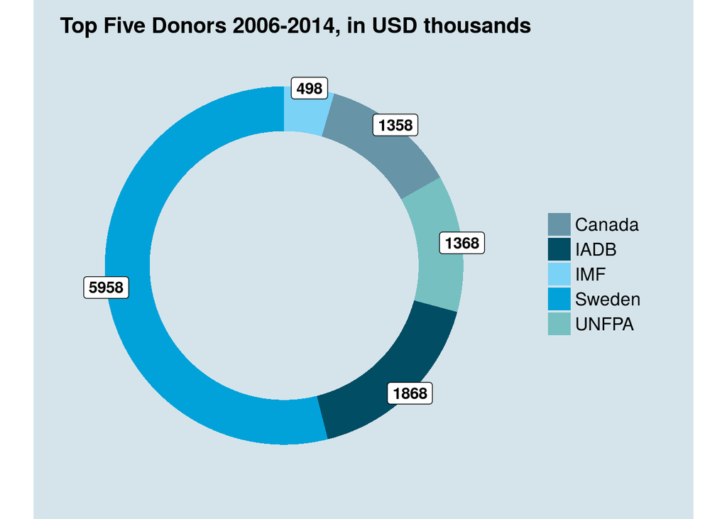

> Fig3. Top 5 Donors

A large share of global support to statistics continues to come from a very small number of providers. The top five providers of development co-operation in statistics for all countries reported in the PRESS (European Commission/EUROSTAT; The World Bank; IMF; FAO; Canada) provided 72% of total commitments in 2014. While Canada is strongly engaged in country-specific aid to statistics, the United Kingdom and Norway are among the top donors for unallocated commitments. Country-Specific commitments accounted for approximately 74% (USD 350 million) in 2014.

This table displays all projects whose Financing Amount is at least 10 000 USD.

| Provider | Projects | Amount | Type | Date |
| --- | --- | --- | --- | --- |
| **Canada** | NATIONAL SURVEY ON MATERNAL AND CHILD HEALTH / ENQUÊTE NATIONALE SUR LA SANTÉ DES MÈRES ET DES ENFANTS | 1358 | Grant | 2014 |
| **HMN** | Strengthening of Health Information Systems | 50 | Grant | 2008 |
| **IADB** | GUATEMALA: NATIONAL SURVEY OF EMPLOYMENT AND INCOME | 650 | Grant | 2009 |
| **IADB** | GUATEMALA: NATIONAL SURVEY OF QUALITY OF LIFE -ENCOVI 2011- | 500 | Grant | 2010 |
| **IADB** | SUPPORT FOR THE PREPARATION OF CENSUS ACTIVITIES IN GUATEMALA 2012-2013 | 718 | Grant | 2011 |
| **IMF** | Technical Assistance | 43 |  | 2007 |
| **IMF** | Statistics Department: Technical Assistance | 39 |  | 2010 |
| **IMF** | Statistics Department: Technical Assistance | 48 |  | 2011 |
| **IMF** | Statistics Department: Technical Assistance | 148 |  | 2012 |
| **IMF** | Statistics Department: Technical Assistance | 119 |  | 2013 |
| **IMF** | Statistics Department: Technical Assistance | 101 |  | 2014 |
| **Japan** | TC AGGREGATED ACTIVITIES | 76 | Grant | 2006 |
| **Japan** | TC AGGREGATED ACTIVITIES | 70 | Grant | 2007 |
| **Japan** | TC AGGREGATED ACTIVITIES | 21 | Grant | 2008 |
| **Korea** | DISPATCH OF VOLUNTEERS_SENIOR_MINISTRY OF THE INTERIOR | 88 | Grant | 2014 |
| **Spain** | STRENGTHENING OF INE AT THE INSTITUTIONALIZATION OF GENDER APPROACH AND AT PEOPLES STATISTICAL INFORMATION PRODUCTION | 279 | Grant | 2009 |
| **Spain** | CIES PROGRAM STATISTICS INTERNATIONAL COOPERATION . | 49 | Grant | 2011 |
| **Spain** | GUATEMALA 2013, HEALTH, SURVEY ON CHILD-MOTHER HEALTH | 109 | Grant | 2013 |
| **Sweden** | INE STATISTICS SWEDEN STATISTICS SWEDEN | 1899 | Grant | 2006 |
| **Sweden** | ENSMI 2008-2009 ENSMI/MIN. SALUD | 1796 | Grant | 2008 |
| **Sweden** | INE SCB BRIDGE 2010 | 130 | Grant | 2010 |
| **Sweden** | MODERNISATION STATISTICS | 1477 | Grant | 2012 |
| **Sweden** | SUPPORT TO INE:S LIFE SURVEY IN GUATEMALA - SUPPORT TO INE:S SURVEY | 656 | Grant | 2014 |
| **The World Bank** | Monitoring of Statistics in the Health and Education Sectors - TFSCB | 220 | Grant | 2007 |
| **UNFPA** | Municipal statistics - Population Dynamics Linkages | 67 | Grant | 2008 |
| **UNFPA** | Fortalecimiento de Disponibilidad de Datos Estadísticos sobre Población para Promoción del Desarrollo Humano | 201 | Grant | 2010 |
| **UNFPA** | Información estadística para políticas públicas | 1100 | Grant | 2012 |
| **UNICEF** | MONITORING AND REPORTING SYSTEMS ON CHILDREN/WOMEN | 15 | Grant | 2006 |
| **UNICEF** | CP DATA COLLECTION AND ANALYSIS | 10 | Grant | 2008 |
| **UNICEF** | CP RESEARCH AND ANALYSIS | 33 | Grant | 2008 |
| **UNICEF** | NATIONAL STATISTICAL SYSTEMS | 25 | Grant | 2008 |
| **UNICEF** | MONITORING AND REPORTING SYSTEMS ON CHILDREN/WOMEN | 14 | Grant | 2008 |
| **UNICEF** | BIRTH REGISTRATION | 74 | Grant | 2011 |
| **UNICEF** | BIRTH REGISTRATION | 29 | Grant | 2012 |
| **USA** | PROYECTO DE SALUD SANGRE DE CRISTO | 112 | Grant | 2012 |
| **USA** | GUATEMALA MONITORING AND EVALUATION (M&E) PROJECT - PROGRAM DESIGN AND LEARNING | 17 | Grant | 2013 |
| **USA** | GUATEMALA MONITORING AND EVALUATION (M&E) PROJECT - PROGRAM DESIGN AND LEARNING | 15 | Grant | 2013 |
| **USA** | GUATEMALA MONITORING AND EVALUATION (M&E) PROJECT - PROGRAM DESIGN AND LEARNING | 75 | Grant | 2013 |

**Source: PRESS 2016. The report was prepared by the Secretariat of the Partnership in Statistics for Development in the 21st Century (PARIS21)**

[^1]: Multilateral support in this context refers to support coming from multilateral institutions.
[^2]: Country-specific assistance refers to projects for which there is a single country recipient.